# Liens

## Tableaux de bord et cartes

[Kuba Suder’s Coronavirus charts](https://mackuba.eu/corona)

[Carte intéractive ARCGIS par John Hopkins](https://www.arcgis.com/apps/opsdashboard/index.html?fbclid=IwAR1ZLw7GtInzddurFezT4uc6YEYg7O4Qba2uXLwzhTCQCd3-Yym1NMmQH-Y#/bda7594740fd40299423467b48e9ecf6)

[Carte ARCGIS pour le Québec](https://ulaval.maps.arcgis.com/apps/opsdashboard/index.html?fbclid=IwAR0DJYWl-s0KIBfBZIV6-UpoJP0VHpLZyMbrq39MUkwURvj9KBamOHs4SG4#/775aaa4e3a124d6499aeb63bfe8e4ffb)

[Carte de l’OMS](https://who.maps.arcgis.com/apps/opsdashboard/index.html#/c88e37cfc43b4ed3baf977d77e4a0667)

[Coronavirus tracker](https://gorkang.shinyapps.io/2020-corona/)

[Canada COVID-19 interactive growth rate explorer](https://mountainmath.ca/shiny/canada_covid-19/?_inputs_&level=%22province%22&metric=%22Confirmed%22&start_cutoff=100)

## Infographiques

[Coronavirus : suivez la propagation de la pandémie en France et dans le monde, Le Monde](https://www.lemonde.fr/les-decodeurs/article/2020/02/27/en-carte-visualisez-la-propagation-mondiale-de-l-epidemie-de-coronavirus_6031092_4355770.html)

[Why outbreaks like coronavirus spread exponentially, and how to flatten the curve, Washington Post](https://www.washingtonpost.com/graphics/2020/world/corona-simulator/)

[COVID-19 Coronavirus Infographic Data Pack](https://informationisbeautiful.net/visualizations/covid-19-coronavirus-infographic-datapack/)

[Coronavirus tracked: the latest figures as the pandemic spreads, Financial Times](https://www.ft.com/coronavirus-latest)

## Vidéos

[Minute Physics: Comment savoir si nous gagnons contre le COVID-19 ?](https://www.youtube.com/watch?v=54XLXg4fYsc&feature=youtu.be&fbclid=IwAR1bgOW3g9nUk-HyyxagS_ivcTpaDiRBrM_VrEA0m_Wmx9Ue0B4ghMn9wQs)

[3Blue1Brown: Simuler une épidémie](https://www.youtube.com/watch?v=gxAaO2rsdIs&list=TLPQMjgwMzIwMjCJg96eXPBsYg&index=2)

[3Blue1Brown: Exponential growth and epidemics](https://www.youtube.com/watch?v=Kas0tIxDvrg&t=456s)

## Données

[worldometer](https://www.worldometers.info/coronavirus/)

[Coronavirus Disease (COVID-19) – Statistics and Research](https://ourworldindata.org/coronavirus)

[Document pdf du MSSS concernant la veille épidémiologique des maladies respiratoires sévères infectieuses et Ebola](https://www.msss.gouv.qc.ca/professionnels/documents/veille-epidemiologique.pdf)

[Données du Canada](https://www.canada.ca/en/public-health/services/diseases/2019-novel-coronavirus-infection.html?topic=tilelink) [Données du Canada](https://www.canada.ca/en/public-health/services/diseases/2019-novel-coronavirus-infection/health-professionals/epidemiological-summary-covid-19-cases.html?topic=tilelink)

[COVID19-Canada](https://wzmli.github.io/COVID19-Canada/)

[Données de l’Islande](https://www.icelandreview.com/ask-ir/whats-the-status-of-covid-19-in-iceland/)

[Google Mobility Data](https://www.google.com/covid19/mobility/)

## Simulateurs

[Coronavirus 10-day forecast U. of Melbourne](http://covid19.science.unimelb.edu.au/)

[Models of SEIRS epidemic dynamics with extensions, including network-structured populations, testing, contact tracing, and social distancing](https://github.com/ryansmcgee/seirsplus)

[Ben Bolker’s simulator list](https://docs.google.com/spreadsheets/d/1hUZlVDPfa5C8KgURoP_3dAiUQgI6rdb7A5e_g8NcPaY/edit#gid=0)

[McMaster Pandemic](https://github.com/bbolker/McMasterPandemic)

[Modeling COVID-19 Spread vs Healthcare Capacity](https://alhill.shinyapps.io/COVID19seir/)

## Initiatives collaboratives

[RECON COVID-19 hub](https://github.com/reconhub/covid19hub)

[FOLDING@HOME](https://foldingathome.org/covid19/)

[Collaborative Google Sheets on Policy Measures Against Covid19](https://docs.google.com/spreadsheets/d/1tYfD3vvSEaW3Cq9-UZoDtlKIfaMMVJq8XnV9XJUdK3s/edit#gid=0)

## Blogs et autres

[Top 35 R resources on Novel COVID-19 Coronavirus](https://www.statsandr.com/blog/top-r-resources-on-covid-19-coronavirus/)

[Infectious diseases and nonlinear differential equations](https://fabiandablander.com/r/Nonlinear-Infection.html)

[Wikipedia: Compartmental models in epidemiology](https://en.wikipedia.org/wiki/Compartmental_models_in_epidemiology#The_SEIR_model)

## Références pour les curieux

Anderson, R. M., Heesterbeek, H., Klinkenberg, D., & Hollingsworth, T. D. (2020). How will country-based mitigation measures influence the course of the COVID-19 epidemic? *The Lancet*, *395*(10228), 931–934. https://doi.org/10.1016/S0140-6736(20)30567-5

Anderson, R. M., & May, R. M. (1979). Population biology of infectious diseases: Part I. *Nature*, *280*(5721), 361–367. https://doi.org/10.1038/280361a0

Blackwood, J. C., & Childs, L. M. (2018). An introduction to compartmental modeling for the budding infectious disease modeler. *Letters in Biomathematics*, *5*(1), 195–221. https://doi.org/10.1080/23737867.2018.1509026

Brauer, F. (2017). Mathematical epidemiology: Past, present, and future. *Infectious Disease Modelling*, *2*(2), 113–127. https://doi.org/10.1016/j.idm.2017.02.001

Brauer, F. (2019). The Final Size of a Serious Epidemic. *Bulletin of Mathematical Biology*, *81*(3), 869–877. https://doi.org/10.1007/s11538-018-00549-x

Chatzilena, A., van Leeuwen, E., Ratmann, O., Baguelin, M., & Demiris, N. (2019). Contemporary statistical inference for infectious disease models using Stan. *Epidemics*, *29*, 100367. https://doi.org/10.1016/j.epidem.2019.100367

Chowell, G., Sattenspiel, L., Bansal, S., & Viboud, C. (2016). Mathematical models to characterize early epidemic growth: A review. *Physics of Life Reviews*, *18*, 66–97. https://doi.org/10.1016/j.plrev.2016.07.005

Delamater, P. L., Street, E. J., Leslie, T. F., Yang, Y. T., & Jacobsen, K. H. (2019). Complexity of the Basic Reproduction Number (R <sub>0</sub> ). *Emerging Infectious Diseases*, *25*(1), 1–4. https://doi.org/10.3201/eid2501.171901

Hébert-Dufresne, L., Althouse, B. M., Scarpino, S. V., & Allard, A. (2020). Beyond $R_0$: The importance of contact tracing when predicting epidemics. *ArXiv:2002.04004 [Physics, q-Bio]*. http://arxiv.org/abs/2002.04004

Heesterbeek, H., Anderson, R. M., Andreasen, V., Bansal, S., De Angelis, D., Dye, C., Eames, K. T. D., Edmunds, W. J., Frost, S. D. W., Funk, S., Hollingsworth, T. D., House, T., Isham, V., Klepac, P., Lessler, J., Lloyd-Smith, J. O., Metcalf, C. J. E., Mollison, D., Pellis, L., … Isaac Newton Institute IDD Collaboration. (2015). Modeling infectious disease dynamics in the complex landscape of global health. *Science*, *347*(6227), aaa4339–aaa4339. https://doi.org/10.1126/science.aaa4339

House, T., Ross, J. V., & Sirl, D. (2013). How big is an outbreak likely to be? Methods for epidemic final-size calculation. *Proceedings of the Royal Society A: Mathematical, Physical and Engineering Sciences*, *469*(2150), 20120436. https://doi.org/10.1098/rspa.2012.0436

Keeling, M. J., & Eames, K. T. D. (2005). Networks and epidemic models. *Journal of The Royal Society Interface*, *2*(4), 295–307. https://doi.org/10.1098/rsif.2005.0051

Lloyd-Smith, J. O., Schreiber, S. J., Kopp, P. E., & Getz, W. M. (2005). Superspreading and the effect of individual variation on disease emergence. *Nature*, *438*(7066), 355–359. https://doi.org/10.1038/nature04153

Ma, J. (2020). Estimating epidemic exponential growth rate and basic reproduction number. *Infectious Disease Modelling*, *5*, 129–141. https://doi.org/10.1016/j.idm.2019.12.009

Ma, J., Dushoff, J., Bolker, B. M., & Earn, D. J. D. (2014). Estimating Initial Epidemic Growth Rates. *Bulletin of Mathematical Biology*, *76*(1), 245–260. https://doi.org/10.1007/s11538-013-9918-2

Mollison, D., Isham, V., & Grenfell, B. (1994). Epidemics: Models and Data. *Journal of the Royal Statistical Society. Series A (Statistics in Society)*, *157*(1), 115. https://doi.org/10.2307/2983509

Pandemic Influenza Outbreak Research Modelling Team (Pan-InfORM). (2009). Modelling an influenza pandemic: A guide for the perplexed. *Canadian Medical Association Journal*, *181*(3–4), 171–173. https://doi.org/10.1503/cmaj.090885

Ridenhour, B., Kowalik, J. M., & Shay, D. K. (2014). Unraveling *R* <sub>0</sub>: Considerations for Public Health Applications. *American Journal of Public Health*, *104*(2), e32–e41. https://doi.org/10.2105/AJPH.2013.301704

Santillana, M., Tuite, A., Nasserie, T., Fine, P., Champredon, D., Chindelevitch, L., Dushoff, J., & Fisman, D. (2018). Relatedness of the incidence decay with exponential adjustment (IDEA) model, “Farr’s law” and SIR compartmental difference equation models. *Infectious Disease Modelling*, *3*, 1–12. https://doi.org/10.1016/j.idm.2018.03.001

St-Onge, G., Thibeault, V., Allard, A., Dubé, L. J., & Hébert-Dufresne, L. (2020). School closures, event cancellations, and the mesoscopic localization of epidemics in networks with higher-order structure. *ArXiv:2003.05924 [Nlin, Physics:Physics]*. http://arxiv.org/abs/2003.05924

Sun, P., Lu, X., Xu, C., Sun, W., & Pan, B. (2020). Understanding of COVID‐19 based on current evidence. *Journal of Medical Virology*, jmv.25722. https://doi.org/10.1002/jmv.25722

Tuite, A., Fisman, D. N., & Greer, A. L. (2020). *Mathematical modeling of COVID-19 transmission and mitigation strategies in the population of Ontario, Canada* [Preprint]. Epidemiology. https://doi.org/10.1101/2020.03.24.20042705

Viboud, C., Simonsen, L., & Chowell, G. (2016). A generalized-growth model to characterize the early ascending phase of infectious disease outbreaks. *Epidemics*, *15*, 27–37. https://doi.org/10.1016/j.epidem.2016.01.002

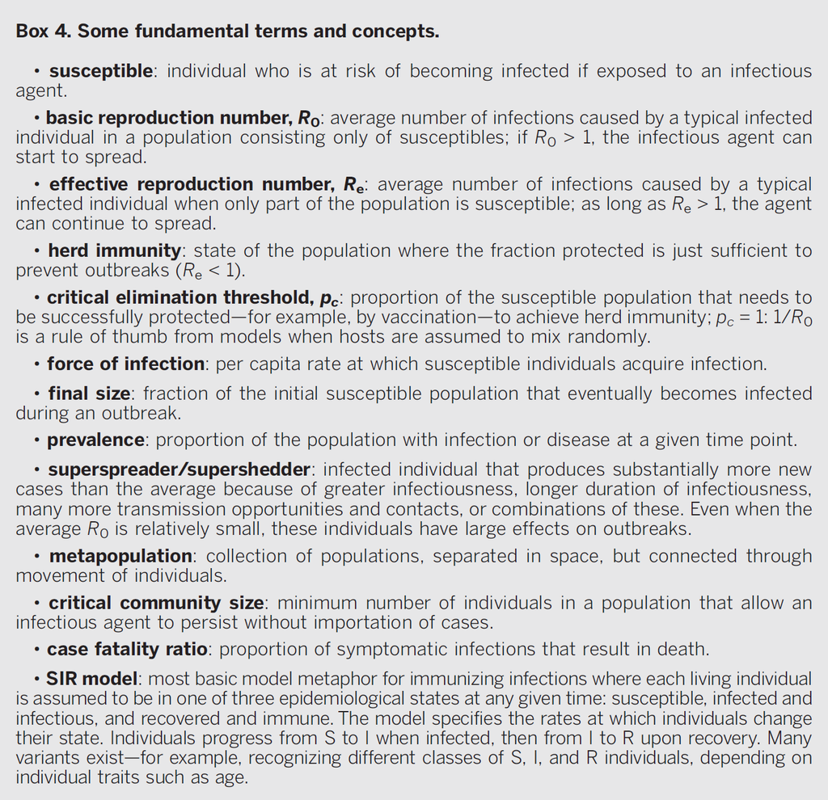

[Heesterbeek et al. (2015)](http://dx.doi.org/10.1126/science.aaa4339)

# Modèles phénoménologiques

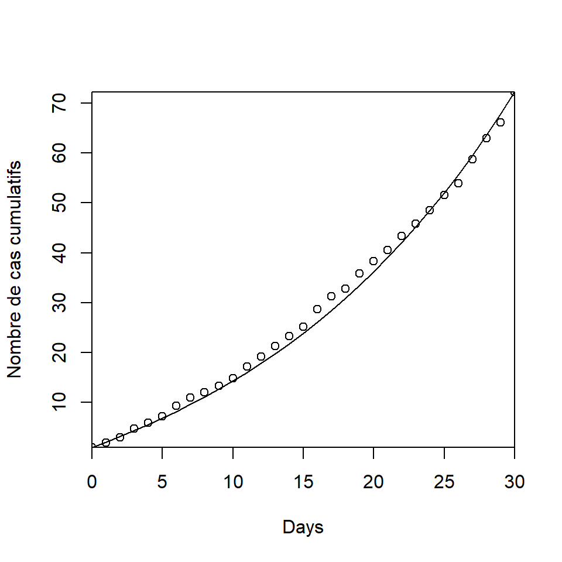

## Exponentiel

$$N(t) = N_{0}e^{rt}$$

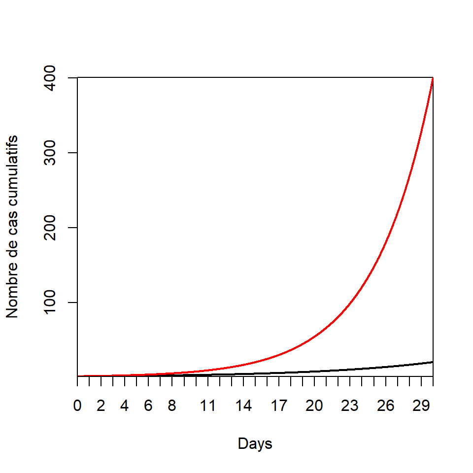

```r
EXP<-function(r,I0=1,days=30,dt=0.01){
    k<-seq(0,days,dt)
    m<-matrix(NA,nrow=length(k),ncol=length(r))
    colnames(m)<-r
    rownames(m)<-k
    m[1,]<-I0
    dN<-function(I){r*I}
    for(i in 2:length(k)){
         m[i,]<-m[i-1,]+dt*dN(m[i-1,])
    }
    m
}

r<-c(0.1,0.2)
days<-30
dt<-0.01
x<-EXP(r=r,I0=1,days=days,dt=dt)
matplot(x,type="l",xlab="Days",ylab="Nombre de cas cumulatifs",lty=1,lwd=2,xaxs="i",yaxs="i",log="",xaxt="n")
axis(1,at=seq(1,nrow(x),by=1/dt),labels=rownames(x)[seq(1,nrow(x),by=1/dt)])
```

## Logistique

$$\frac{dN}{dt} = rN(t)\left(1-\frac{N(t)}{K}\right)$$

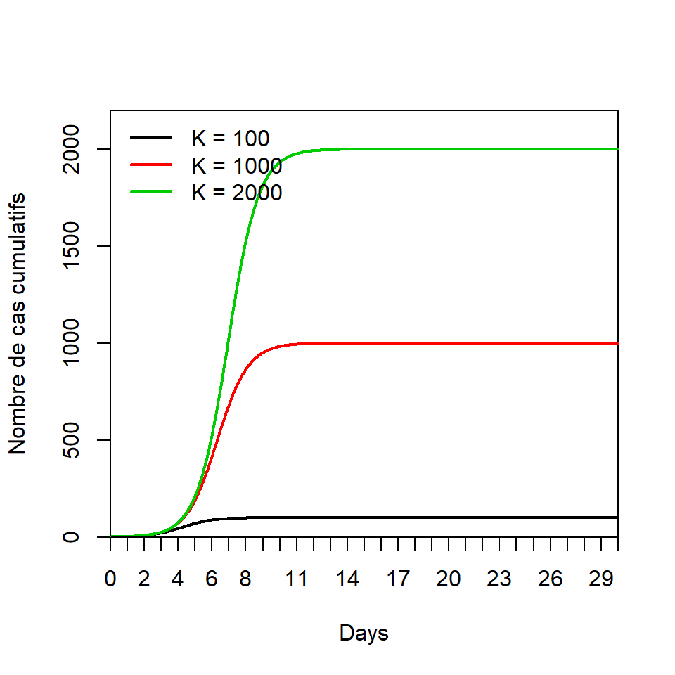

```r
RLG<-function(r,a=1,K=c(100,1000,2000),I0=1,dt=0.01,days=30){
    k<-seq(0,days,dt)
    m<-matrix(NA,nrow=length(k),ncol=length(K))
    colnames(m)<-K
    rownames(m)<-k
    m[1,]<-I0
    dI<-function(I){r*I*(1-(I/K)^a)}
    for(i in 2:length(k)){
        m[i,]<-m[i-1,]+dt*dI(m[i-1,])
    }
    m
}

K<-c(100,1000,2000)
dt<-0.01
days<-30
x<-RLG(r=1.1,a=1,K=K,I0=1,dt=dt,days=days)
matplot(x,type="l",xlab="Days",ylab="Nombre de cas cumulatifs",lty=1,lwd=2,xaxs="i",yaxs="i",log="",xaxt="n",ylim=c(0,max(K)*1.1))
axis(1,at=seq(1,nrow(x),by=1/dt),labels=rownames(x)[seq(1,nrow(x),by=1/dt)])
legend("topleft",legend=paste("K =",K),bty="n",col=1:3,lwd=2)
```

## Richards

$$\frac{dN}{dt} = rN(t)\left(1-\left(\frac{N(t)}{K}\right)^a\right)$$

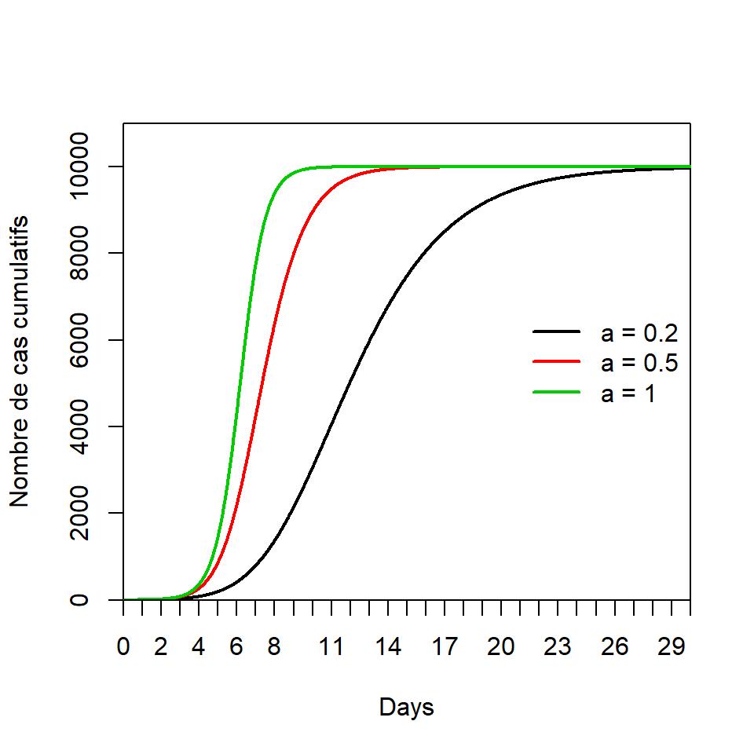

```r
RLG<-function(r,a,K,I0,dt,days){
    k<-seq(0,days,dt)
    m<-matrix(NA,nrow=length(k),ncol=length(a))
    colnames(m)<-a
    rownames(m)<-k
    m[1,]<-I0
    dI<-function(I){r*I*(1-(I/K)^a)}
    for(i in 2:length(k)){
        m[i,]<-m[i-1,]+dt*dI(m[i-1,])
    }
    m
}

a<-c(0.2,0.5,1)
days<-30
dt<-0.01
x<-RLG(r=1.5,a=a,K=10000,I0=1,dt=dt,days=days)
matplot(x,type="l",xlab="Days",ylab="Nombre de cas cumulatifs",lty=1,lwd=2,xaxs="i",yaxs="i",log="",xaxt="n",ylim=c(0,10000*1.1))
axis(1,at=seq(1,nrow(x),by=1/dt),labels=rownames(x)[seq(1,nrow(x),by=1/dt)])
legend("right",legend=paste("a =",a),bty="n",col=1:3,lwd=2)
```

## Generalized Growth Model

$$\frac{dN}{dt} = rN(t)^{p}$$

Où $p$ est un paramètre de décélération.

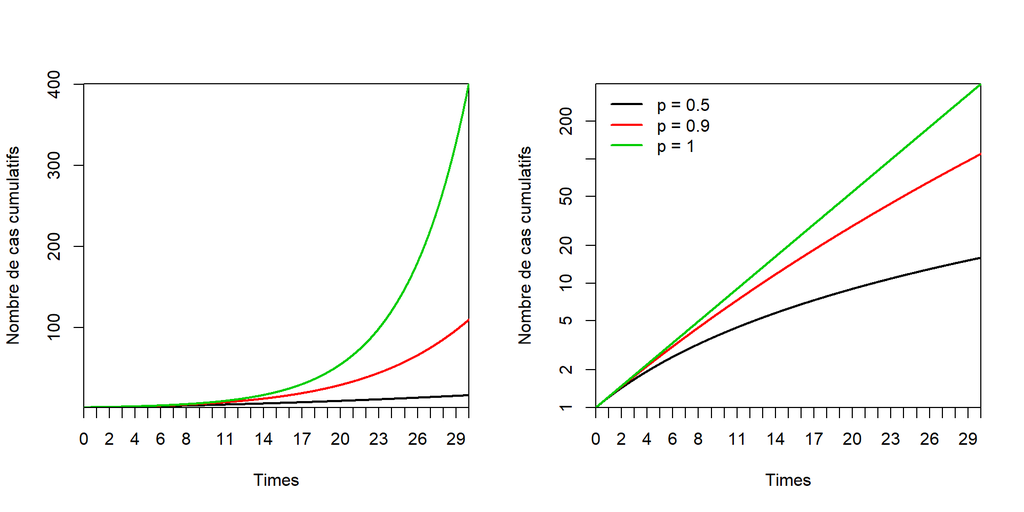

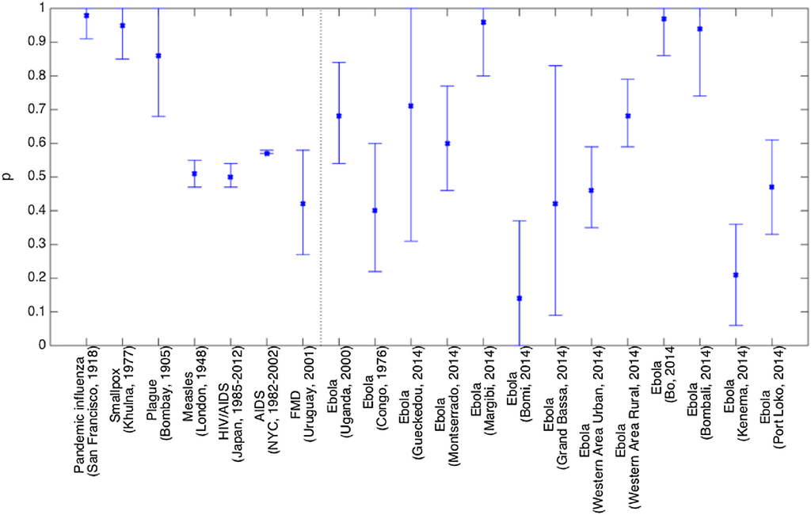

```r
GGM<-function(r,p,I0=1,dt=0.1,days=5){
    k<-seq(0,days,dt)
    m<-matrix(NA,nrow=length(k),ncol=length(p))
    colnames(m)<-p
    rownames(m)<-k
    m[1,]<-I0
    dI<-function(I){r*I^p}
    for(i in 2:length(k)){
         m[i,]<-m[i-1,]+dt*dI(m[i-1,])
    }
    m
}

p<-c(0.5,0.9,1)
days<-30
dt<-0.01
x<-GGM(r=0.2,p=p,I0=1,dt=dt,days=days)
par(mfrow=c(1,2))
matplot(x,type="l",xlab="Times",ylab="Nombre de cas cumulatifs",lty=1,lwd=2,xaxs="i",yaxs="i",log="",xaxt="n")
axis(1,at=seq(1,nrow(x),by=1/dt),labels=rownames(x)[seq(1,nrow(x),by=1/dt)])
matplot(x,type="l",xlab="Times",ylab="Nombre de cas cumulatifs",lty=1,lwd=2,xaxs="i",yaxs="i",log="y",xaxt="n")
axis(1,at=seq(1,nrow(x),by=1/dt),labels=rownames(x)[seq(1,nrow(x),by=1/dt)])
legend("topleft",legend=paste("p =",p),bty="n",col=1:length(p),lwd=2)
```

[Viboud et al. (2015)](https://doi.org/10.1016/j.epidem.2016.01.002)

# Modèles compartimentaux

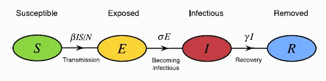

[Ma et al. (2014)](https://doi.org/10.1007/s11538-013-9918-2)

## SIR

$$\mathbf{S}usceptible - \mathbf{I}nfected - \mathbf{R}ecovered$$
$$\frac{dS}{dt} = -\beta \frac{SI}{N}$$
$$\frac{dI}{dt} = \beta \frac{SI}{N}-\gamma I$$
$$\frac{dR}{dt} = \gamma I$$
$$\frac{d}{dt}(S+I+R) = 0$$

$\beta$: taux de transmission

$\gamma$: taux de guérison

$N$: population totale

$$R_{0} = \frac{\beta}{\gamma}$$

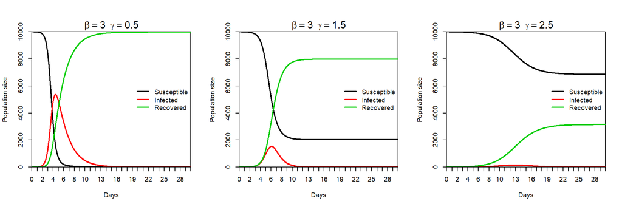

```r
SIR<-function(S0,I0,beta,gamma,dt,days){
    N0<-S0+I0
    k<-seq(0,days,dt)
    m<-matrix(NA,ncol=3,nrow=length(k))
    colnames(m)<-c("S","I","R")
    rownames(m)<-k
    m[1,]<-c(S0,I0,N0-S0-I0)
    dS<-function(S,I){-beta*I*S/N0}
    dI<-function(S,I){beta*I*S/N0-gamma*I}
    for(i in 2:length(k)){
        S<-m[i-1,1]
        I<-m[i-1,2]
        m[i,1]<-S+dt*dS(S,I)
        m[i,2]<-I+dt*dI(S,I)
    }
    m[,3]<-N0-m[,1]-m[,2]
    m
}

beta<-c(3,3,3)
gamma<-c(0.5,1.5,2.5)
days<-30
dt<-0.01

par(mfrow=c(1,3))
l<-lapply(seq_along(beta),function(i){
     x<-SIR(S0=10^4,I0=1,beta=beta[i],gamma=gamma[i],dt=dt,days=days)
  matplot(x,type="l",xlab="Days",ylab="Population size",lty=1,lwd=2,xaxs="i",yaxs="i",xaxt="n")
  axis(1,at=seq(1,nrow(x),by=1/dt),labels=rownames(x)[seq(1,nrow(x),by=1/dt)])
  mtext(side=3,text=bquote(beta == .(beta[i]) ~~ gamma == .(gamma[i])))
  legend("right",legend=c("Susceptible","Infected","Recovered"),bty="n",col=1:3,lwd=2)
})
```

## SEIR

$$\mathbf{S}usceptible - \mathbf{E}xposed - \mathbf{I}nfectious - \mathbf{R}ecovered$$
$$\frac{dS}{dt} = -\beta \frac{SI}{N}$$
$$\frac{dE}{dt} = \beta \frac{SI}{N}-\sigma E$$
$$\frac{dI}{dt} = \sigma E-\gamma I$$
$$\frac{dR}{dt} = \gamma I$$
$$\frac{d}{dt}(S+E+I+R) = 0$$

$\beta$: taux de transmission

$\sigma$: taux de développement des symptômes

$\gamma$: taux de guérison

$N$: population totale

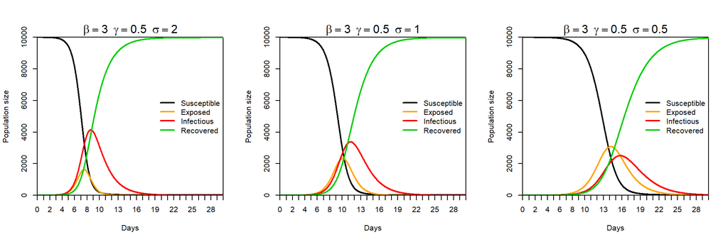

```r
SEIR<-function(S0,I0,beta,gamma,sigma,dt,days){
    N0<-S0+I0
    k<-seq(0,days,dt)
    m<-matrix(NA,ncol=4,nrow=length(k))
    colnames(m)<-c("S","E","I","R")
    rownames(m)<-k
    m[1,]<-c(S0,I0,0,0)
    dS<-function(S,I){-beta*I*S/N0}
    dE<-function(S,I){beta*I*S/N0-sigma*E}
    dI<-function(S,I){sigma*E-gamma*I}
    for(i in 2:length(k)){
        S<-m[i-1,1]
        E<-m[i-1,2]
        I<-m[i-1,3]
        m[i,1]<-S+dt*dS(S,I)
        m[i,2]<-E+dt*dE(S,I)
        m[i,3]<-I+dt*dI(S,I)
    }
    m[,4]<-N0-m[,1]-m[,2]-m[,3]
    m
}

beta<-c(3,3,3)
sigma<-c(2,1,0.5)
gamma<-c(0.5,0.5,0.5)
dt<-0.01
days<-30

par(mfrow=c(1,3))
l<-lapply(seq_along(beta),function(i){
     x<-SEIR(S0=10^4,I0=1,beta=beta[i],sigma=sigma[i],gamma=gamma[i],dt=dt,days=days)
  cols<-c(1,"orange",2,3)
     matplot(x,type="l",xlab="Days",ylab="Population size",lty=1,lwd=2,xaxs="i",yaxs="i",col=cols,xaxt="n")
     axis(1,at=seq(1,nrow(x),by=1/dt),labels=rownames(x)[seq(1,nrow(x),by=1/dt)])
  mtext(side=3,text=bquote(beta == .(beta[i]) ~~ gamma == .(gamma[i])~~ sigma == .(sigma[i]) ))
  legend("right",legend=c("Susceptible","Exposed","Infectious","Recovered"),bty="n",col=cols,lwd=2)
})
```

Supposition du modèle **SIR**

Immunité complète (ou mort) suite à l’infection

Tous les individus sont également susceptibles

Population fermée (pas de naissances)

Tous les individus sont également suceptibles d’interagir

## SIR avec décélération

$$\beta(t) = \beta_{0}((1-\phi)e^{-qt}+\phi)$$

$\beta_{0}$: taux d’infection initial

$\phi$: proportion de la valeur initiale de $\beta_{0}$ jusqu’où la décroissance se rend

$q$: taux de diminution de $\beta$

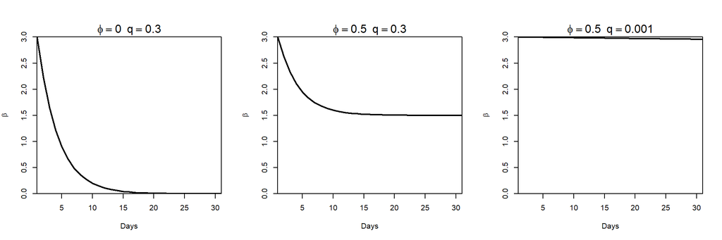

```r
bt<-function(t,beta0,phi,q){beta0*(((1-phi)*exp(-q*t))+phi)}

days<-seq(0,30)
beta0<-c(3,3,3)
phi<-c(0.0,0.5,0.5)
q<-c(0.3,0.3,0.001)

par(mfrow=c(1,3))
l<-lapply(seq_along(beta0),function(i){
    x<-bt(days,beta0[i],q=q[i],phi=phi[i])
    plot(x,type="l",xlab="Days",ylab=expression(beta),lty=1,lwd=2,xaxs="i",yaxs="i",ylim=c(0,max(beta0)))
    mtext(side=3,text=bquote(phi == .(phi[i]) ~~ q == .(q[i])))
})
```

$$\frac{dS}{dt} = -\beta(t) \frac{SI}{N}$$
$$\frac{dI}{dt} = \beta(t) \frac{SI}{N}-\gamma I$$
$$\frac{dR}{dt} = \gamma I$$
$$\beta(t) = \beta_{0}((1-\phi)e^{-qt}+\phi)$$

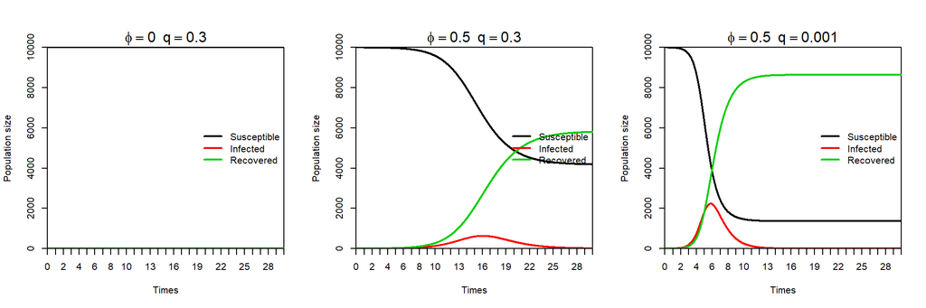

```r
SIRb<-function(S0,I0,beta0,gamma,q,phi,dt,days){
    N0<-S0+I0
    k<-seq(0,days,dt)
    m<-matrix(NA,ncol=4,nrow=length(k))
    colnames(m)<-c("S","I","R","beta")
    rownames(m)<-k
    m[1,]<-c(S0,I0,N0-S0-I0,beta0)
    bt<-function(t){beta0*(((1-phi)*exp(-q*t))+phi)}
    dS<-function(b,S,I){-b*I*S/N0}
    dI<-function(b,S,I){b*I*S/N0-gamma*I}
    for(i in 2:length(k)){
        S<-m[i-1,1]
        I<-m[i-1,2]
        beta<-bt(i)
        m[i,1]<-S+dt*dS(beta,S,I)
        m[i,2]<-I+dt*dI(beta,S,I)
    }
    m[,3]<-N0-m[,1]-m[,2]
    m
}

beta0<-c(3,3,3)
gamma<-c(1,1,1)
phi<-c(0.1,0.1,0.1)
q<-c(0.0025,0.0015,0.0001)
days<-30
dt<-0.01
phi<-c(0.0,0.5,0.5)
q<-c(0.3,0.3,0.001)


par(mfrow=c(1,3))
l<-lapply(seq_along(beta0),function(i){
    x<-SIRb(S0=10^4,I0=1,beta0=beta0[i],gamma=gamma[i],q=q[i],phi=phi[i],dt=dt,days=days)
    matplot(x,type="l",xlab="Times",ylab="Population size",lty=1,lwd=2,xaxs="i",yaxs="i",xaxt="n")
    axis(1,at=seq(1,nrow(x),by=1/dt),labels=rownames(x)[seq(1,nrow(x),by=1/dt)])
    mtext(side=3,text=bquote(phi == .(phi[i]) ~~ q == .(q[i])))
    legend("right",legend=c("Susceptible","Infected","Recovered"),bty="n",col=1:3,lwd=2)
    x
})
```

# Extensions

## Types de modèles

### Stochastique

Allen, L. J. S. (2017). A primer on stochastic epidemic models: Formulation, numerical simulation, and analysis. *Infectious Disease Modelling*, *2*(2), 128–142. https://doi.org/10.1016/j.idm.2017.03.001

### Sur réseaux

Keeling, M. J., & Eames, K. T. D. (2005). Networks and epidemic models. *Journal of The Royal Society Interface*, *2*(4), 295–307. https://doi.org/10.1098/rsif.2005.0051

## Population multiples

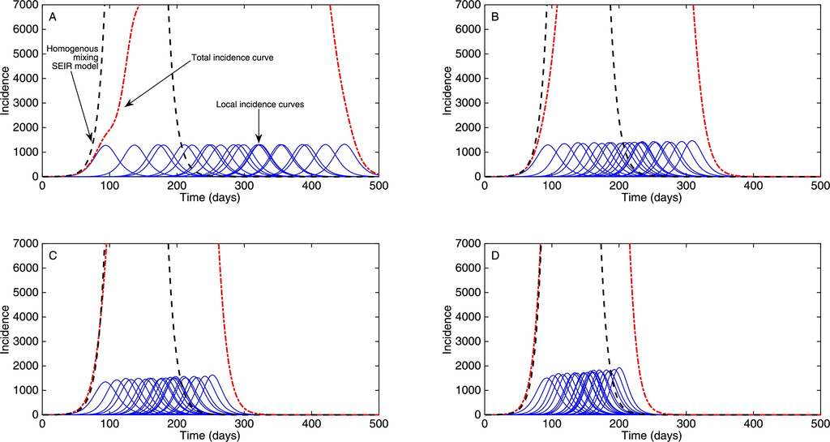

[Chowell et al. (2016)](https://doi.org/10.1016/j.plrev.2016.07.005)

## Hétérogénéité dans les contacts

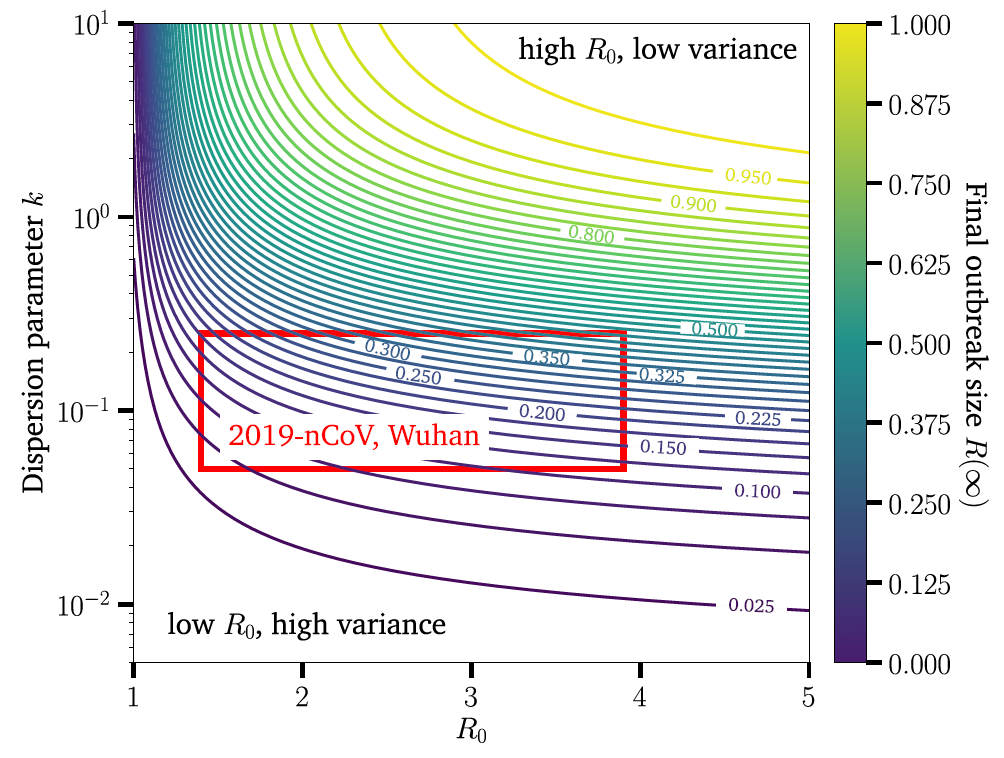

[Hébert-Dufresne et al. (2020)](https://arxiv.org/abs/2002.04004)

## Distanciation sociale

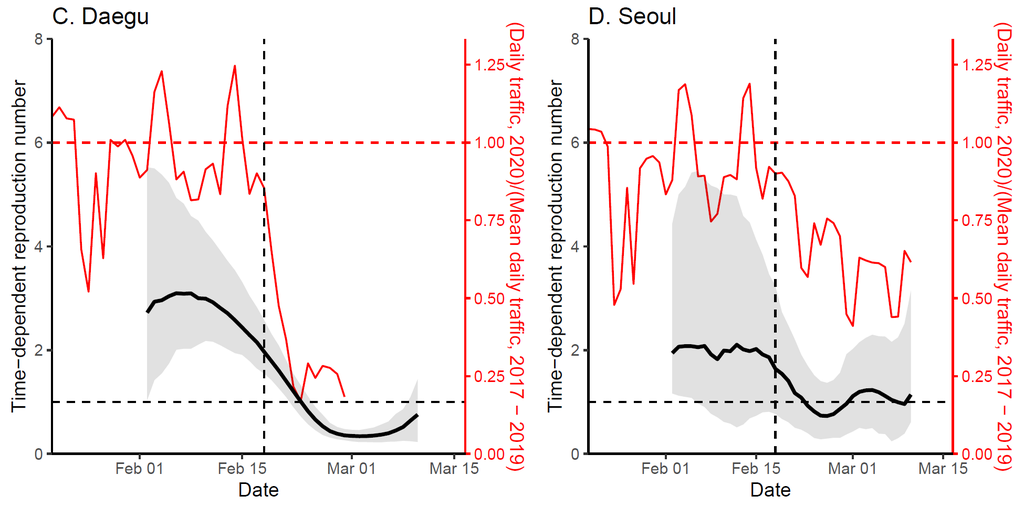

[Park et al. (2020)](https://doi.org/10.1101/2020.03.27.20045815)